# Downstream Dashboard Dashboard — User Research Feedback Report

Compiled from survey responses.  
**DRAFT - in development**

Published

April 2026

## 1 Executive Summary

**11 test users** participated in a usability evaluation of the JPE Dashboard, an interactive tool for exploring discrete water quality and fish genetics datasets. Participants represented a range of professional roles, including staff from government and academic agencies.

The dashboard received positive usability ratings across key interface components:

- Buttons and controls average score: **3.8/5**
- Visualizations average score: **3.7/5**
- Layout and organization average score: **3.6/5**

Qualitative feedback highlighted four recurring themes: navigation and interface structure, controls and filter interactions, data visualization and coverage, and system language and messaging. Recommended improvements primarily relate to refining interactive controls, clarifying how data is presented, and expanding functionality in the genetics module.

### 1.1 Prioritized Recommendations

[output not shown]

## 2 Respondent Overview

### 2.2 Dataset Familiarity

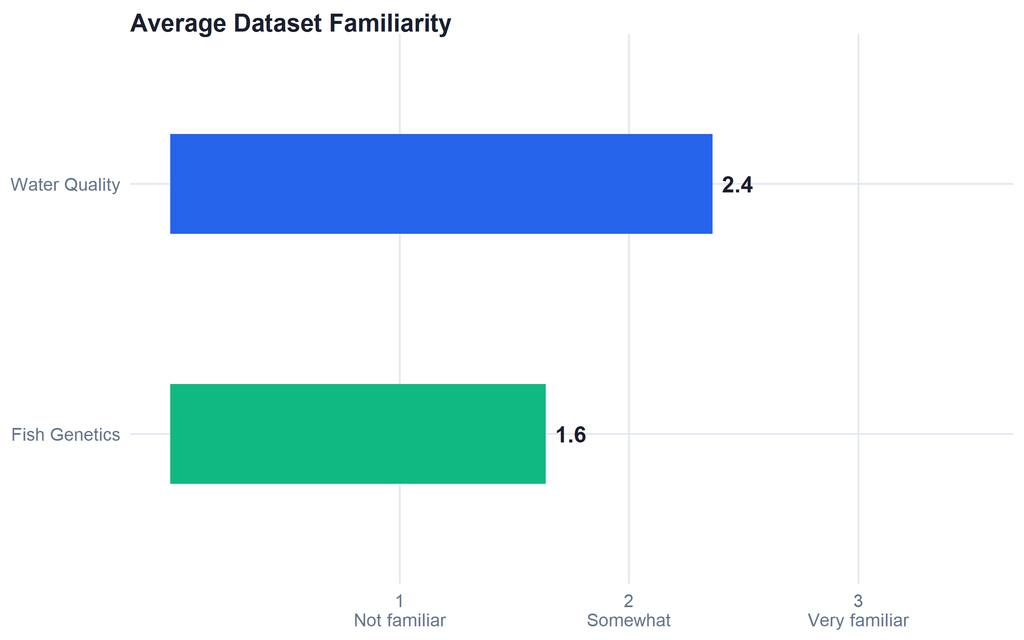

Average self-reported familiarity (1 = not familiar, 3 = very familiar)

### 2.3 Prior Dashboard Experience

| Used dashboards before? | Percent of total participants |
| --- | --- |
| No | 9% |
| Yes | 91% |

## 3 Usability Ratings

### 3.1 Intuitiveness

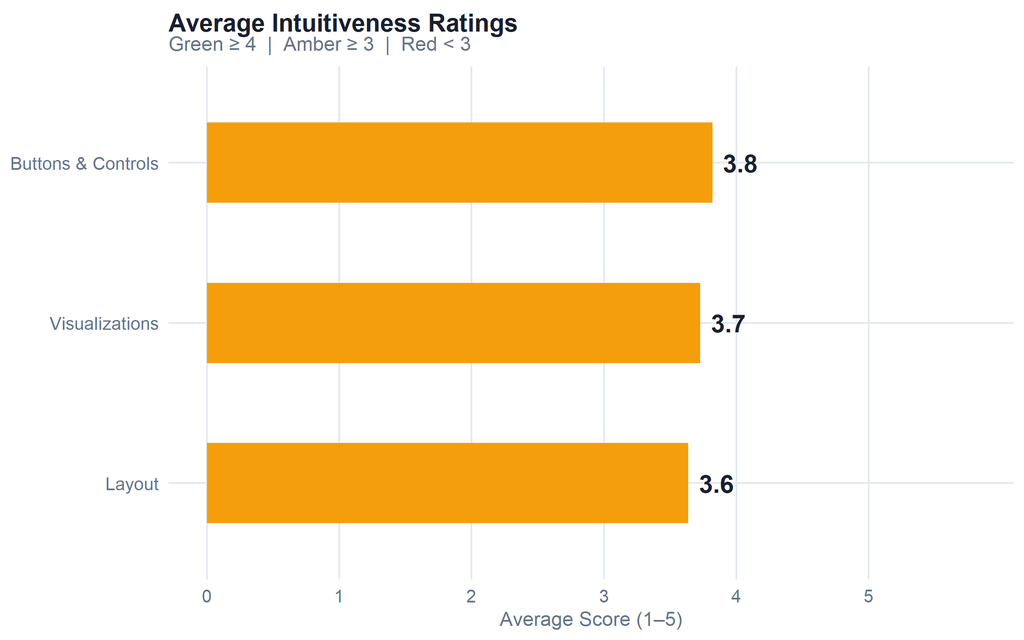

Average intuitiveness scores (1–5 scale)

## 4 Task Completion

Participants completed four guided analytical tasks designed to assess the dashboard’s ability to support typical data exploration workflows. These tasks required users to navigate the interface, filter and compare datasets, and interpret both water quality and fish genetics information across multiple sites and time periods. The table below describes each task, and the figure summarizes how participants rated the ease of completing them.

- **Task 1 (Water Quality):** Identify whether peaks in chlorophyll-a concentrations occurred at San Pablo Bay sites (D41, D41A, NZ325) during 2022–2023.
- **Task 2 (Water Quality):** Determine whether changes in dissolved oxygen levels correlate with shifts in water temperature across San Joaquin sites (C10, D12, D16, D26, P8).
- **Task 3 (Fish Genetics):** Estimate the proportion of Chinook salmon samples on Deer Creek classified as spring run in 2025.
- **Task 4 (Fish Genetics):** Identify which creek — Battle or Clear Creek — had a greater number of early Greb 1L RoSA genotypes between 2023 and 2025.

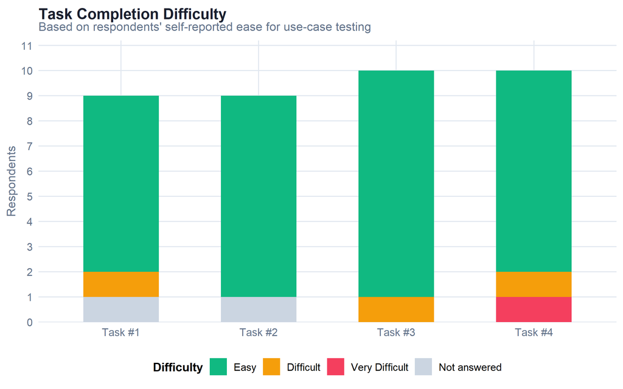

Self-reported ease of completing four guided analytical tasks

## 5 Qualitative Feedback

Participants were asked to provide open-ended feedback following completion of the usability tasks. Responses addressed overall ease of use, navigation, clarity of visualizations, and potential areas for improvement. Individual comments were reviewed and organized into recurring themes, which are summarized below.

**Navigation/Interface**

- “At first I wasn’t sure where to find the Water Quality and Genetics tabs… I wasn’t expecting them at the top of the page.”
- “Going between sites and analytes got pretty confusing. Options would appear/disappear.”
- “Seems good for finding something specific but difficult to explore openly.”
- “Inactive site selection was confusing.”

**Controls/Filters**

- “Year slider… difficult to use rather than choosing a date range.”
- “Could use summary data type (month, year) for box plots.”
- “Year toggle label should be ‘Water Year’.”
- “Tick marks in the year toggle were confusing.”
- “Would like to go more specific than one year.”
- “Options appearing/disappearing when selecting sites/analytes.”
- “I tried searching just by copying the sites into the search. P8 didn’t come up in the search bar as written. Had to write P08. Again, easy to fix, just annoying.”
- “I’m not sure if I like the auto-zoom/pan; when I want to select multiple points on the map I have to zoom back out every time.”
- “The only way to see which stations are inactive is by the dot color on the map but once you select it you can’t tell anymore.”

**Visualization/Data**

- “Would like additional information in the genetics dataset.”
- “Would like to see exact number of fish instead of proportion.”
- “Would like to see what days fish were caught instead of yearly total.”
- “Label all rivers on the map.”
- “Add stations upstream of Sacramento at Hood.”
- “Compare field length assignments to genetic results.”
- “Connections to EDI pages / metadata / downloads.”
- “Box plots across time instead of one big box plot.”
- “Water quality tab doesn’t show cities so it was a little confusing to orient myself not being familiar with the delta.”

**Language/Messages**

- “Need a ‘no data’ message when inactive site selected.”
- “Unclear if inactive means currently inactive or always inactive.”
- “Dropdown empty but no explanation.”
- “Not clear why analyte options disappeared.”

## 6 Appendix

### 6.1 Appendix A: Action Item Checklist

This checklist summarizes recommended improvements identified from participant feedback, organized by theme. Items can be used to prioritize development tasks.

#### 6.1.1 Navigation / Interface

- Relocate the Water Quality and Genetics tabs from the top of the page to a more conventional location (e.g. sidebar or persistent top nav) - *Decided to keep tab design as it currently is. This item was low priority and might be addressed in the future*
- Restructure the Overview page — replace long paragraphs with concise topic sentences and bullet points - *LOW*
- Add a clear section heading that states the dashboard purpose upfront - *LOW*
- Sort station names alphabetically with station ID in parentheses - *LOW*
- Remove auto-zoom to selected sites - *LOW*
- Add color differentiation for selected sites that are active vs inactive - *LOW*

#### 6.1.2 Controls / Filters

- Replace the year slider with checkboxes or a date range picker - *HIGH*
- Remove tick marks between years on the year toggle to prevent user confusion - *MEDIUM*
- Relabel the year toggle to say “Water Year” instead of “Year” - *LOW*
- Fix the site/analyte dropdowns so options do not disappear unexpectedly when switching between sites - *LOW*
- Allow users to select within-year date ranges for more granular filtering - *LOW*

#### 6.1.3 Visualization / Data

- Add river labels to the water quality map - *MEDIUM*
- Add city labels to the water quality map - *MEDIUM*
- Add water quality monitoring stations upstream of Sacramento at Hood - *The Environmental Monitoring Program (EMP) monitors water conditions across the San Francisco Estuary*
- Display raw fish counts alongside proportions in the genetics module - *LOW (ADD EXPLANATION OF TOOLTIP)*
- Add daily or event-level catch data rather than annual totals only - *?*
- Add water year type and flow/export data overlays to the genetics dashboard - *Since this is not priority, team decided to omit this since these data is available elsewhere*
- Build a comparison view for field length-at-date assignments vs. genetic run assignments - *MEDIUM*
- Replace the single large box plot with time-series summary plots (monthly or annual) - *Decided to keep box plots and time series*
- Add an option to toggle between average, maximum, minimum, and 7-day average values - *NA Discrete water quality sampling occurs mostly once a month at each monitoring station*
- Add links or connections to EDI pages for metadata, citations, and downloads - *LOW*
- Clarify the difference between surface and bottom sensor measurements (e.g. “Dissolved Oxygen” vs. “(bottom) Dissolved Oxygen”) - *MEDIUM*
- Indicate whether more historical data or future data will be available - *Data collection methods langugage explains the site shifts from historical sites, if any*

#### 6.1.4 Language / Messages

- Clarify what “inactive” means in the site selector (currently inactive vs. inactive across full time range) - *LOW*
- Add a chart subtitle or title note specifying what data is shown (e.g. “Average daily concentrations”) - *Determined that axis titles were sufficient to communicate data shown*
- Add a label reminding users that water quality data shown is discrete monthly samples - *LOW - ADD EXPLANATION*